# Unit2_CaseStudy_HNguyen_NDevadoss_RSimhambhatla_RMandava

## Unit 2: Missing Data - Imputation Techniques

### Team: Hieu Nguyen, Nithya Devadoss, Ramesh Simhambhatla, Ramya Mandava

### Date: 11/04/2018

## Abstract

In Statistics, to create meaningful model, a tidy or clean data set is extremely important. So, data examination and cleaing is the pre-face of any modelling activity. Data cleaning is the process of detecting and correcting (or removing) corrupt or inaccurate records from a record set, table, or database and refers to identifying incomplete, incorrect, inaccurate or irrelevant parts of the data and then replacing, modifying, or deleting the dirty or coarse data. In this exercise, we would experiment with data imputation process of replacing missing data with substituted values using the Boston Housing Dataset. The data consists of 506 observations of price of houses in various places in Boston. We would then apply different types of missingness, such as Missing Completely at Random (MACR), Missing at Random (MAR) and Missing Not at Random (MNAR) to compare the (linear) model performance in predicting Boston Housing prices.

## Introduction

To experiment with types of missingness and model performance, we would use Boston Housing dataset available in sklearn package. The data set has 506 observations and 13 attributes. This data set do not have any missing data, so we would experiment with forcebly imputing missing values with multiple scenarios.

Attribute Information:

```
1. CRIM      per capita crime rate by town
2. ZN        proportion of residential land zoned for lots over
             25,000 sq.ft.
3. INDUS     proportion of non-retail business acres per town
4. CHAS      Charles River dummy variable (= 1 if tract bounds
             river; 0 otherwise)
5. NOX       nitric oxides concentration (parts per 10 million)
6. RM        average number of rooms per dwelling
7. AGE       proportion of owner-occupied units built prior to 1940
8. DIS       weighted distances to five Boston employment centres
9. RAD       index of accessibility to radial highways
10. TAX      full-value property-tax rate per $10,000
11. PTRATIO  pupil-teacher ratio by town
12. B        1000(Bk - 0.63)^2 where Bk is the proportion of blacks
             by town
13. LSTAT    % lower status of the population
```

### STEP1:

#### Using Sklearn, get the Boston Housing Dataset. Fit a Linear Regressor to the data as a baseline. There is no need to do cross-validation. We are exploring the change in results. What is the loss and what are the goodness of fit parameters? This will be our baseline for comparison.

In this excercise, we will use Python libraries to load and maninpuate data, and to run the model.

```python
%matplotlib inline

import numpy as np
import pandas as pd
import matplotlib.pyplot as plt
import sklearn


import seaborn as sns
```

```python
from sklearn.datasets import load_boston
boston = load_boston()
```

```python
bos = pd.DataFrame(boston.data)

bos.columns = boston.feature_names
bos.head()
```

|  | CRIM | ZN | INDUS | CHAS | NOX | RM | AGE | DIS | RAD | TAX | PTRATIO | B | LSTAT |
| --- | --- | --- | --- | --- | --- | --- | --- | --- | --- | --- | --- | --- | --- |
| 0 | 0.00632 | 18.0 | 2.31 | 0.0 | 0.538 | 6.575 | 65.2 | 4.0900 | 1.0 | 296.0 | 15.3 | 396.90 | 4.98 |
| 1 | 0.02731 | 0.0 | 7.07 | 0.0 | 0.469 | 6.421 | 78.9 | 4.9671 | 2.0 | 242.0 | 17.8 | 396.90 | 9.14 |
| 2 | 0.02729 | 0.0 | 7.07 | 0.0 | 0.469 | 7.185 | 61.1 | 4.9671 | 2.0 | 242.0 | 17.8 | 392.83 | 4.03 |
| 3 | 0.03237 | 0.0 | 2.18 | 0.0 | 0.458 | 6.998 | 45.8 | 6.0622 | 3.0 | 222.0 | 18.7 | 394.63 | 2.94 |
| 4 | 0.06905 | 0.0 | 2.18 | 0.0 | 0.458 | 7.147 | 54.2 | 6.0622 | 3.0 | 222.0 | 18.7 | 396.90 | 5.33 |

```python
df1 = bos[bos.isnull().any(axis=1)]
df1
```

|  | CRIM | ZN | INDUS | CHAS | NOX | RM | AGE | DIS | RAD | TAX | PTRATIO | B | LSTAT |
| --- | --- | --- | --- | --- | --- | --- | --- | --- | --- | --- | --- | --- | --- |

The data set doesn't have any missing data in the data set to begin with.

```python
bos['PRICE'] = boston.target
bos.head()
```

|  | CRIM | ZN | INDUS | CHAS | NOX | RM | AGE | DIS | RAD | TAX | PTRATIO | B | LSTAT | PRICE |
| --- | --- | --- | --- | --- | --- | --- | --- | --- | --- | --- | --- | --- | --- | --- |
| 0 | 0.00632 | 18.0 | 2.31 | 0.0 | 0.538 | 6.575 | 65.2 | 4.0900 | 1.0 | 296.0 | 15.3 | 396.90 | 4.98 | 24.0 |
| 1 | 0.02731 | 0.0 | 7.07 | 0.0 | 0.469 | 6.421 | 78.9 | 4.9671 | 2.0 | 242.0 | 17.8 | 396.90 | 9.14 | 21.6 |
| 2 | 0.02729 | 0.0 | 7.07 | 0.0 | 0.469 | 7.185 | 61.1 | 4.9671 | 2.0 | 242.0 | 17.8 | 392.83 | 4.03 | 34.7 |
| 3 | 0.03237 | 0.0 | 2.18 | 0.0 | 0.458 | 6.998 | 45.8 | 6.0622 | 3.0 | 222.0 | 18.7 | 394.63 | 2.94 | 33.4 |
| 4 | 0.06905 | 0.0 | 2.18 | 0.0 | 0.458 | 7.147 | 54.2 | 6.0622 | 3.0 | 222.0 | 18.7 | 396.90 | 5.33 | 36.2 |

```python
bos.describe()
```

|  | CRIM | ZN | INDUS | CHAS | NOX | RM | AGE | DIS | RAD | TAX | PTRATIO | B | LSTAT | PRICE |
| --- | --- | --- | --- | --- | --- | --- | --- | --- | --- | --- | --- | --- | --- | --- |
| count | 506.000000 | 506.000000 | 506.000000 | 506.000000 | 506.000000 | 506.000000 | 506.000000 | 506.000000 | 506.000000 | 506.000000 | 506.000000 | 506.000000 | 506.000000 | 506.000000 |
| mean | 3.593761 | 11.363636 | 11.136779 | 0.069170 | 0.554695 | 6.284634 | 68.574901 | 3.795043 | 9.549407 | 408.237154 | 18.455534 | 356.674032 | 12.653063 | 22.532806 |
| std | 8.596783 | 23.322453 | 6.860353 | 0.253994 | 0.115878 | 0.702617 | 28.148861 | 2.105710 | 8.707259 | 168.537116 | 2.164946 | 91.294864 | 7.141062 | 9.197104 |
| min | 0.006320 | 0.000000 | 0.460000 | 0.000000 | 0.385000 | 3.561000 | 2.900000 | 1.129600 | 1.000000 | 187.000000 | 12.600000 | 0.320000 | 1.730000 | 5.000000 |
| 25% | 0.082045 | 0.000000 | 5.190000 | 0.000000 | 0.449000 | 5.885500 | 45.025000 | 2.100175 | 4.000000 | 279.000000 | 17.400000 | 375.377500 | 6.950000 | 17.025000 |
| 50% | 0.256510 | 0.000000 | 9.690000 | 0.000000 | 0.538000 | 6.208500 | 77.500000 | 3.207450 | 5.000000 | 330.000000 | 19.050000 | 391.440000 | 11.360000 | 21.200000 |
| 75% | 3.647423 | 12.500000 | 18.100000 | 0.000000 | 0.624000 | 6.623500 | 94.075000 | 5.188425 | 24.000000 | 666.000000 | 20.200000 | 396.225000 | 16.955000 | 25.000000 |
| max | 88.976200 | 100.000000 | 27.740000 | 1.000000 | 0.871000 | 8.780000 | 100.000000 | 12.126500 | 24.000000 | 711.000000 | 22.000000 | 396.900000 | 37.970000 | 50.000000 |

```
Text(0.5,1,'Prices vs Predicted prices: $Y_i$ vs $\\hat{Y}_i$')
```

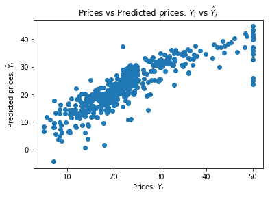

```python
from sklearn.linear_model import LinearRegression

lm = LinearRegression()
X = bos.iloc[:,0:-1]  #iloc gives the positional locations, so 'all rows' and 'all but the last column'
Y_true = bos.iloc[:,-1]
lm.fit(X,Y_true)

Y_pred = lm.predict(X)

plt.scatter(Y_true, Y_pred)
plt.xlabel("Prices: $Y_i$")
plt.ylabel("Predicted prices: $\hat{Y}_i$")
plt.title("Prices vs Predicted prices: $Y_i$ vs $\hat{Y}_i$")
```

```python
lm.score(X,Y_true)
```

```
0.7406077428649427
```

The model without any changes to existing data set showing a $R^{2}$= 0.7406077428649427 (Goodness of Fit)

```python
from sklearn.metrics import mean_squared_error, mean_absolute_error
print("MSE: ", mean_squared_error(Y_pred,Y_true))
print("MAE: ", mean_absolute_error(Y_pred,Y_true))
#lm.score(X,Y_true)
```

```
('MSE: ', 21.8977792176875)
('MAE: ', 3.2729446379969396)
```

Mean Squared Error (MSE) and Mean Absolute Error (MAE) are the measure of loss or the differece between a target value and prediction of the variable.

### In the exercise, we would take these values as baseline to compare with upcoming tests when we experiment with various scenarios of missing types.

### STEP 2: (Repeat)

### Missing Completely at Random (MCAR)

#### For select between 1, 5, 10, 20, 33 and 50% of your data on a single column (Completely at Random), replace the present value with a NAN and then perform an imputation of that value. In each case, perform a fit with the imputed data and compare the loss and goodness of fit to your baseline.

In this section, we will experiment with imputing data to **AGE** feature by replacing the data limiting to different number of instances.

**Missing Completely at Random (MCAR)** exists when missing values are randomly distributed across all observations. Missingness in given variable does not depend on any other variable, whether observed or unobserved.

```python
import random
random.random()
```

```
0.7716269018353936
```

```python
X.shape[0]
```

```
506
```

```python
df1 = X[X.isnull().any(axis=1)]
df1
```

|  | CRIM | ZN | INDUS | CHAS | NOX | RM | AGE | DIS | RAD | TAX | PTRATIO | B | LSTAT |
| --- | --- | --- | --- | --- | --- | --- | --- | --- | --- | --- | --- | --- | --- |

For 1% of the data selection

```python
from sklearn.linear_model import LinearRegression
limit1 = [0.01,0.05,0.1,0.2,0.33,0.5]
MSE = []
MAE = []
Scr = []
```

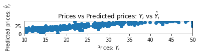

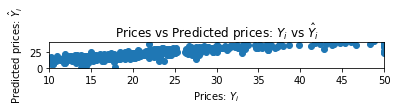

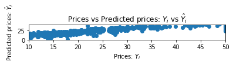

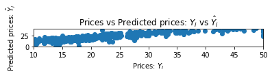

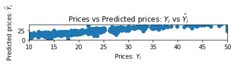

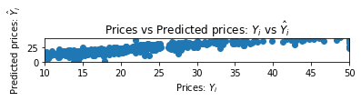

```python
cnt = 1
X_age = X
for j in range(0,len(limit1)):
    for i in range(X_age.shape[0]):
        miss_1 = random.random()
        #miss_2 = random.random()
        if miss_1 < limit1[j]:
            X_age.iloc[i,6] = np.nan
    X_age.loc[X_age.iloc[:,6].isna(),'AGE'].shape
    sub = X_age['AGE'].median()
    X_age.loc[X_age.iloc[:,6].isna(),'AGE'] = sub
    lm.fit(X_age,Y_true)
    Y_pred = lm.predict(X_age)
    cnt += 1
    plt.subplot(7, 1, cnt)
    plt.axis([10, 50, 0, 40])
    plt.scatter(Y_true, Y_pred)
    plt.xlabel("Prices: $Y_i$")
    plt.ylabel("Predicted prices: $\hat{Y}_i$")
    plt.title("Prices vs Predicted prices: $Y_i$ vs $\hat{Y}_i$")
    plt.show()
    MSE.append(mean_squared_error(Y_pred,Y_true))
    MAE.append(mean_absolute_error(Y_pred,Y_true))
    Scr.append(lm.score(X_age,Y_true))

   # cnt += 1    plt.subplot(7, 1, cnt)    plt.axis([10, 50, 0, 40])
```

```python
for i in range(0,len(MSE)):
    print 'The Mean Squared Error for ->MCAR',int(limit1[i]*100), '% of data selected is',MSE[i]
```

```
The Mean Squared Error for ->MCAR 1 % of data selected is 21.89764294296161
The Mean Squared Error for ->MCAR 5 % of data selected is 21.895049835703688
The Mean Squared Error for ->MCAR 10 % of data selected is 21.870254969920943
The Mean Squared Error for ->MCAR 20 % of data selected is 21.886990983479652
The Mean Squared Error for ->MCAR 33 % of data selected is 21.88379937040795
The Mean Squared Error for ->MCAR 50 % of data selected is 21.897153468799214
```

```python
for i in range(0,len(MAE)):
    print 'The Mean Absolute Error for ->MCAR',int(limit1[i]*100), '% of data selected is',MAE[i]
```

```
The Mean Absolute Error for ->MCAR 1 % of data selected is 3.2729675546150943
The Mean Absolute Error for ->MCAR 5 % of data selected is 3.2734364662634907
The Mean Absolute Error for ->MCAR 10 % of data selected is 3.2704940594708845
The Mean Absolute Error for ->MCAR 20 % of data selected is 3.278815061158606
The Mean Absolute Error for ->MCAR 33 % of data selected is 3.2693432966817855
The Mean Absolute Error for ->MCAR 50 % of data selected is 3.272352425843225
```

```python
for i in range(0,len(Scr)):
    print 'The Score for ->MCAR',int(limit1[i]*100), '% of data selected is',Scr[i]
```

```
The Score for ->MCAR 1 % of data selected is 0.7406093571203605
The Score for ->MCAR 5 % of data selected is 0.7406400740226518
The Score for ->MCAR 10 % of data selected is 0.7409337839982986
The Score for ->MCAR 20 % of data selected is 0.7407355359344525
The Score for ->MCAR 33 % of data selected is 0.7407733424951243
The Score for ->MCAR 50 % of data selected is 0.7406151552337916
```

#### Compared to baseline statistics (Baseline: $R^{2}$: 0.7406077428649427; MSE: 21.897779217687496; MAE: 3.2729446379969227), we did not observe very significant loss or change in goodness of fit test while implementing imputation for Missing Completely at Random (MCAR) experiments on feature 'Age'.

### Step 3:

### Missing at Random (MAR)

#### Take 2 different columns and create data "Missing at Random" when controlled for a third variable (i.e., if variable Z > 30%, then variable X, Y are randomly missing). Make runs 10, 20 and 30% missing data imputed via your best guess. Repeat your fit and comparison to baseline.

In this section, we will experiment with imputing data for **NOX and DIS** features when **CHAS = 1** by replacing the data limiting to number of instances - 10%, 20%, and 30%.

**Missing at Random (MAR)** data reflect a systematic rather than random pattern of missingness with our controlled variable CHAS==1.

```python
X_twocol = X
X2 = X_twocol[X_twocol['CHAS']==1]
```

[output not shown]

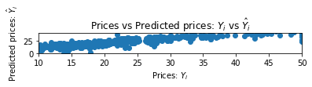

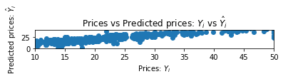

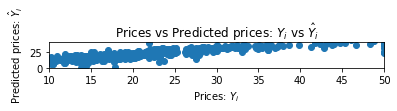

```python
limit2 = [0.1,0.2,0.3]
MSE1 = []
MAE1 = []
Scr1 = []
cnt1 = 1
for j in range(0,len(limit2)):
    for i in range(X2.shape[0]):
        miss_1 = random.random()
        miss_2 = random.random()
        if miss_1 < limit2[j]:
            X2.iloc[i,4] = np.nan

        if miss_2 < limit2[j]:
            X2.iloc[i,7] = np.nan
    X_twocol[X_twocol['CHAS']==1] = X2
    X_twocol.loc[X_twocol.iloc[:,4].isna(),'NOX'].shape
    sub = X_twocol['NOX'].mean()
    X_twocol.loc[X_twocol.iloc[:,4].isna(),'NOX'] = sub
    sub = X_twocol['DIS'].mean()
    X_twocol.loc[X_twocol.iloc[:,7].isna(),'DIS'] = sub
    lm.fit(X_twocol,Y_true)
    Y_pred = lm.predict(X_twocol)
    cnt1 += 1
    plt.subplot(7, 1, cnt1)
    plt.axis([10, 50, 0, 40])
    plt.scatter(Y_true, Y_pred)
    plt.xlabel("Prices: $Y_i$")
    plt.ylabel("Predicted prices: $\hat{Y}_i$")
    plt.title("Prices vs Predicted prices: $Y_i$ vs $\hat{Y}_i$")
    plt.show()
    Scr1.append(lm.score(X_twocol,Y_true))
    MSE1.append(mean_squared_error(Y_pred,Y_true))
    MAE1.append(mean_absolute_error(Y_pred,Y_true))
```

```python
for i in range(0,len(MSE1)):
    print 'The Mean Squared Error for ->MAR',int(limit2[i]*100), '% of data selected is',MSE1[i]
```

```
The Mean Squared Error for ->MAR 10 % of data selected is 21.860397660026756
The Mean Squared Error for ->MAR 20 % of data selected is 21.569653981003782
The Mean Squared Error for ->MAR 30 % of data selected is 22.34703209306859
```

```python
for i in range(0,len(MAE1)):
    print 'The Mean Absolute Error for ->MAR',int(limit2[i]*100), '% of data selected is',MAE1[i]
```

```
The Mean Absolute Error for ->MAR 10 % of data selected is 3.2747774266415726
The Mean Absolute Error for ->MAR 20 % of data selected is 3.260169479281187
The Mean Absolute Error for ->MAR 30 % of data selected is 3.268950568700861
```

## Step 4:

## Missing Not at Random

#### Create a Missing Not at Random pattern in which 25% of the data is missing for a single column. Impute your data, fit the results and compare to a baseline

In this section, we will experiment with imputing data to RM (average Room Size) feature by replacing upto 25% of the obsersations.

**Missing Not at Random** happens when missingness depends at least in part on unobserved variables

```python
#5.885500 - Missing at Not Random
X_rm = X
#X2 = X_rm[X_twocol['CHAS']==1]
```

```python
len(X[X['RM']<5.8855])
```

```
127
```

```python
X2 = X_rm[X_rm['RM']<=6.208]
```

```python
limit = .25
for i in range(X2.shape[0]):
    miss_1 = random.random()
    print(miss_1)
    if miss_1 < limit:
        X2.iloc[i,5] = np.nan
```

[output not shown]

[output not shown]

[output cut: 192 more lines]

[output not shown]

```python
X_rm[X_rm['RM']<=6.208] = X2
```

```python
sub =  X_rm['RM'].mean()
X_rm.loc[X_rm.iloc[:,5].isna(),'RM'] = sub
```

```
Text(0.5,1,'Prices vs Predicted prices: $Y_i$ vs $\\hat{Y}_i$')
```

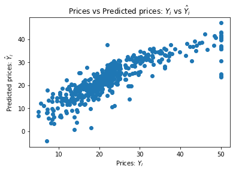

```python
from sklearn.linear_model import LinearRegression

lm.fit(X_rm,Y_true)

Y_pred = lm.predict(X_rm)

plt.scatter(Y_true, Y_pred)
plt.xlabel("Prices: $Y_i$")
plt.ylabel("Predicted prices: $\hat{Y}_i$")
plt.title("Prices vs Predicted prices: $Y_i$ vs $\hat{Y}_i$")
```

```python
lm.score(X_rm,Y_true)
print 'The Score for ->MNAR',lm.score(X_rm,Y_true)
```

```
The Score for ->MNAR 0.7352860745710461
```

```python
print("Mean Squared Error (MSE):", mean_squared_error(Y_pred,Y_true))
print("Mean Absolute Error (MAE):",mean_absolute_error(Y_pred,Y_true))
```

[output not shown]

#### Compared to baseline statistics (Baseline: $R^{2}$: 0.7406077428649427; MSE: 21.897779217687496; MAE: 3.2729446379969227), we did observe no siginficant change in loss to both MSE and MAE, and slight decrease in goodness of fit test while implementing imputation for Missing Not at Random (MNAR) experiment on RM (<= 6.208) feature by imputing missing data into approximately 25% of observations.

### Conclusion

##### In this case study, we have experimented different types of missingness, such as Missing Completely at Random (MACR), Missing at Random (MAR) and Missing Not at Random (MNAR) to compare the (linear) model performance in predicting Boston Housing prices. We have compared goodness of fit -> $R^{2}$, Losses (MAE, and MSE) with various scenarios, and observe very slight or no differences. The data set we used have only 506 observations, so we may need to experiment with large data sets to find significant differences. In real world, these techniques are very handy and essential as most data sets require certain degree of imputation.

### References

Loss https://heartbeat.fritz.ai/5-regression-loss-functions-all-machine-learners-should-know-4fb140e9d4b0

Goodness of fit http://www.medicine.mcgill.ca/epidemiology/joseph/courses/EPIB-621/fit.pdf

Prof Slater's Class material and sample notebook

Thank you!!